# Lab 7

Kent Codding

2023-10-27

#read in BACS data

```r
df <- read.csv("BACS(1).csv")
```

# Step 1

```r
mod.pois <- glm(df$BACS ~ df$years_since_burn +
df$area_small_pines +
df$hardwood_cov_perc
  , family = "poisson")
summary(mod.pois)
```

```
##
## Call:
## glm(formula = df$BACS ~ df$years_since_burn + df$area_small_pines +
##     df$hardwood_cov_perc, family = "poisson")
##
## Deviance Residuals:
##     Min       1Q   Median       3Q      Max
## -3.4363  -1.4353  -0.8066   0.3630   6.0875
##
## Coefficients:
##                        Estimate Std. Error z value Pr(>|z|)
## (Intercept)           1.7756590  0.0648134  27.397  < 2e-16 ***
## df$years_since_burn  -0.1393793  0.0187578  -7.430 1.08e-13 ***
## df$area_small_pines  -0.0008761  0.0002511  -3.489 0.000484 ***
## df$hardwood_cov_perc -0.0604147  0.0056306 -10.730  < 2e-16 ***
## ---
## Signif. codes:  0 '***' 0.001 '**' 0.01 '*' 0.05 '.' 0.1 ' ' 1
##
## (Dispersion parameter for poisson family taken to be 1)
##
##     Null deviance: 1264.99  on 286  degrees of freedom
## Residual deviance:  873.11  on 283  degrees of freedom
## AIC: 1352
##
## Number of Fisher Scoring iterations: 6
```

numerically, residual deviance / df > 1.5, which provides evidence of overdispersion

## visualization

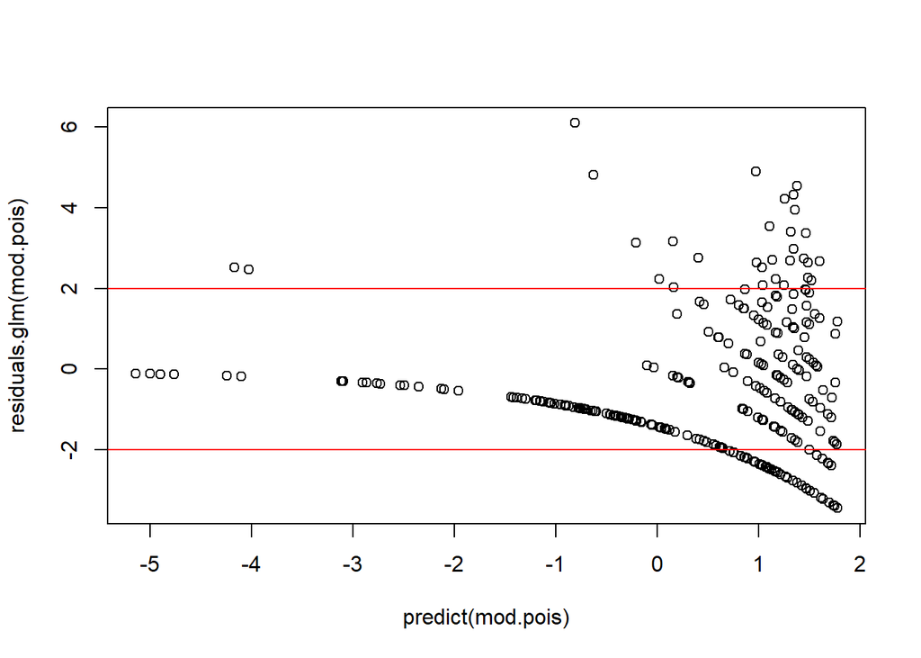

```r
plot(residuals.glm(mod.pois) ~ predict(mod.pois))
abline(h = 2, col = "red")
abline(h = -2, col = "red")
```

The variance changes within the range of predicted values, suggesting that the variance is not fixed. Therefore, overdispersion is present.

# Step 2

```r
library(countreg)
mod.ZIP <- countreg::zeroinfl(
    BACS ~ years_since_burn + area_small_pines + hardwood_cov_perc | #count
    Shrub, #binomial
  data = df, dist = "poisson")
summary(mod.ZIP)
```

```
##
## Call:
## countreg::zeroinfl(formula = BACS ~ years_since_burn + area_small_pines +
##     hardwood_cov_perc | Shrub, data = df, dist = "poisson")
##
## Pearson residuals:
##     Min      1Q  Median      3Q     Max
## -1.6600 -0.7170 -0.4434  0.3855  8.5957
##
## Count model coefficients (poisson with log link):
##                     Estimate Std. Error z value Pr(>|z|)
## (Intercept)        1.8416339  0.0756841  24.333  < 2e-16 ***
## years_since_burn  -0.0750090  0.0235261  -3.188  0.00143 **
## area_small_pines  -0.0004292  0.0002869  -1.496  0.13457
## hardwood_cov_perc -0.0463830  0.0064724  -7.166 7.71e-13 ***
##
## Zero-inflation model coefficients (binomial with logit link):
##              Estimate Std. Error z value Pr(>|z|)
## (Intercept) -2.936578   0.474836  -6.184 6.23e-10 ***
## Shrub        0.048552   0.008082   6.007 1.89e-09 ***
## ---
## Signif. codes:  0 '***' 0.001 '**' 0.01 '*' 0.05 '.' 0.1 ' ' 1
##
## Number of iterations in BFGS optimization: 13
## Log-likelihood: -558.8 on 6 Df
```

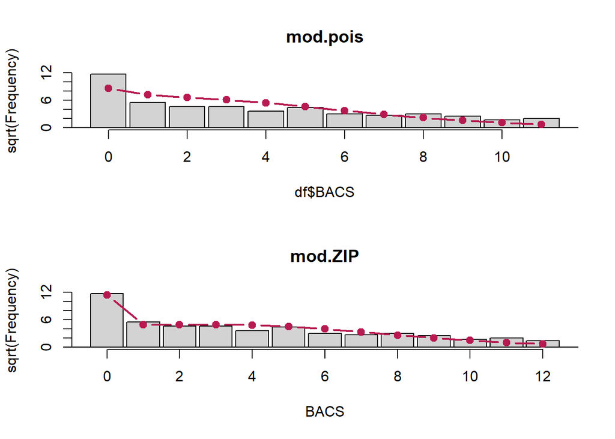

```r
par(mfrow = c(2,1))

rootogram(mod.pois, style = "standing")
rootogram(mod.ZIP, style = "standing")
```

The ZIP model does a much better job than the Poisson model at predicting the zeros within the observed data. Thus, the ZIP model is more appropriate.

# Step 3a

```r
mod.ZINB <- countreg::zeroinfl(BACS ~
    years_since_burn + area_small_pines + hardwood_cov_perc | #count
    Shrub, # binomial
  data = df,
  dist = "negbin" )
summary(mod.ZINB)
```

```
##
## Call:
## countreg::zeroinfl(formula = BACS ~ years_since_burn + area_small_pines +
##     hardwood_cov_perc | Shrub, data = df, dist = "negbin")
##
## Pearson residuals:
##     Min      1Q  Median      3Q     Max
## -1.0370 -0.6081 -0.3842  0.2461  7.6480
##
## Count model coefficients (negbin with log link):
##                     Estimate Std. Error z value Pr(>|z|)
## (Intercept)        2.0190935  0.1493744  13.517  < 2e-16 ***
## years_since_burn  -0.1688469  0.0391204  -4.316 1.59e-05 ***
## area_small_pines  -0.0007989  0.0005317  -1.503    0.133
## hardwood_cov_perc -0.0509518  0.0073437  -6.938 3.97e-12 ***
## Log(theta)         0.4711089  0.2143754   2.198    0.028 *
##
## Zero-inflation model coefficients (binomial with logit link):
##             Estimate Std. Error z value Pr(>|z|)
## (Intercept) -4.45616    0.90610  -4.918 8.75e-07 ***
## Shrub        0.06221    0.01302   4.779 1.76e-06 ***
## ---
## Signif. codes:  0 '***' 0.001 '**' 0.01 '*' 0.05 '.' 0.1 ' ' 1
##
## Theta = 1.6018
## Number of iterations in BFGS optimization: 15
## Log-likelihood: -500.4 on 7 Df
```

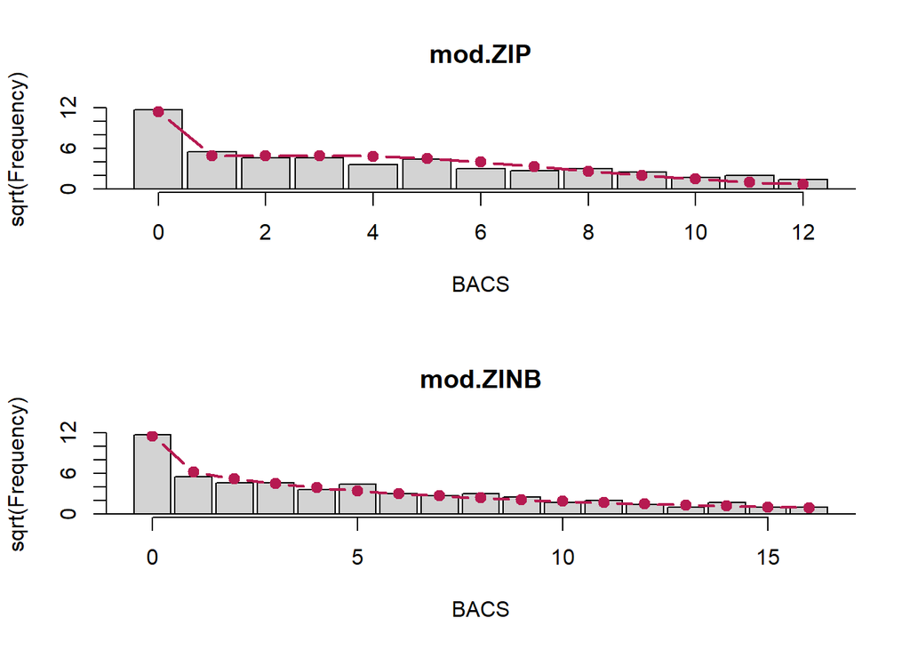

```r
par(mfrow = c(2,1))

rootogram(mod.ZIP, style = "standing")
rootogram(mod.ZINB, style = "standing")
```

Graphically, the ZINB does a better job of predicting the lower, nonzero observed values than the ZIP model due to the presence of an additional parameter to address overdispersion. Numerically, the Log-likelihood is higher and the years_since_burn predictor has an additional level of significance in the count portion of the model for the ZINB.

# Step 4

## drop area_small_pines from count model

```r
mod.ZINB2 <- countreg::zeroinfl(BACS ~
    years_since_burn + hardwood_cov_perc | #count
    Shrub, # binomial
  data = df,
  dist = "negbin" )

library(lmtest)
lrtest(mod.ZINB, mod.ZINB2)
```

```
## Likelihood ratio test
##
## Model 1: BACS ~ years_since_burn + area_small_pines + hardwood_cov_perc |
##     Shrub
## Model 2: BACS ~ years_since_burn + hardwood_cov_perc | Shrub
##   #Df  LogLik Df  Chisq Pr(>Chisq)
## 1   7 -500.37
## 2   6 -501.49 -1 2.2303     0.1353
```

```r
summary(mod.ZINB2)
```

```
##
## Call:
## countreg::zeroinfl(formula = BACS ~ years_since_burn + hardwood_cov_perc |
##     Shrub, data = df, dist = "negbin")
##
## Pearson residuals:
##     Min      1Q  Median      3Q     Max
## -1.0347 -0.6026 -0.3854  0.2520  7.3101
##
## Count model coefficients (negbin with log link):
##                    Estimate Std. Error z value Pr(>|z|)
## (Intercept)        1.892114   0.121572  15.564  < 2e-16 ***
## years_since_burn  -0.162969   0.039039  -4.174 2.99e-05 ***
## hardwood_cov_perc -0.050624   0.007374  -6.865 6.65e-12 ***
## Log(theta)         0.468567   0.214893   2.180   0.0292 *
##
## Zero-inflation model coefficients (binomial with logit link):
##             Estimate Std. Error z value Pr(>|z|)
## (Intercept) -4.46845    0.91291  -4.895 9.84e-07 ***
## Shrub        0.06290    0.01301   4.835 1.33e-06 ***
## ---
## Signif. codes:  0 '***' 0.001 '**' 0.01 '*' 0.05 '.' 0.1 ' ' 1
##
## Theta = 1.5977
## Number of iterations in BFGS optimization: 14
## Log-likelihood: -501.5 on 6 Df
```

having area_small_pines in the model does not significantly improve the model, so it should be dropped: mod.ZINB2 is the better model.

The coefficient for shrub is positive and significant within the binomial portion of the model, so shrub increases the probability of false zeros.

For the counts of BACS, only years_since_burn and hardwood_cov_perc significantly affect the counts of BACS.

# Question 4

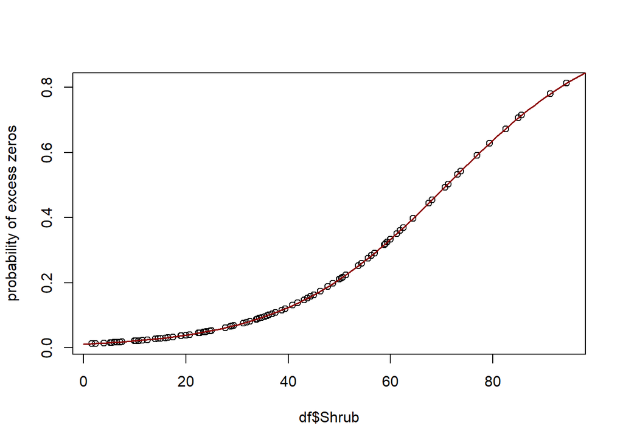

```r
#first make new data set holding all the coviariates constant

ND.Shrub <- expand.grid(list(Shrub = 0:100,
                             years_since_burn = median(df$years_since_burn),
                              hardwood_cov_perc  = median(df$hardwood_cov_perc)))

plot(df$Shrub,predict(mod.ZINB2, type = "zero"),
     ylab = "probability of excess zeros")

#draw fit line using dummy data set
lines(ND.Shrub$Shrub,
        predict(mod.ZINB2, type = "zero", newdata = ND.Shrub),
        lwd = 1.5, col = "darkred")
```

# Question 5

```r
library(pscl)
mod.ZANB <- hurdle(BACS ~
    years_since_burn + hardwood_cov_perc | #count
    Shrub, # binomial
  data = df,
  dist = "negbin" )
summary(mod.ZANB)
```

```
##
## Call:
## hurdle(formula = BACS ~ years_since_burn + hardwood_cov_perc | Shrub,
##     data = df, dist = "negbin")
##
## Pearson residuals:
##     Min      1Q  Median      3Q     Max
## -1.2100 -0.6341 -0.3707  0.3486  3.5548
##
## Count model coefficients (truncated negbin with log link):
##                    Estimate Std. Error z value Pr(>|z|)
## (Intercept)        1.599928   0.129300  12.374   <2e-16 ***
## years_since_burn  -0.050212   0.043074  -1.166   0.2437
## hardwood_cov_perc -0.022845   0.009046  -2.526   0.0116 *
## Log(theta)         0.607904   0.266419   2.282   0.0225 *
## Zero hurdle model coefficients (binomial with logit link):
##              Estimate Std. Error z value Pr(>|z|)
## (Intercept)  1.910824   0.314991   6.066 1.31e-09 ***
## Shrub       -0.039770   0.006271  -6.342 2.27e-10 ***
## ---
## Signif. codes:  0 '***' 0.001 '**' 0.01 '*' 0.05 '.' 0.1 ' ' 1
##
## Theta: count = 1.8366
## Number of iterations in BFGS optimization: 16
## Log-likelihood: -531.2 on 6 Df
```

```r
summary(mod.ZINB2)
```

```
##
## Call:
## countreg::zeroinfl(formula = BACS ~ years_since_burn + hardwood_cov_perc |
##     Shrub, data = df, dist = "negbin")
##
## Pearson residuals:
##     Min      1Q  Median      3Q     Max
## -1.0347 -0.6026 -0.3854  0.2520  7.3101
##
## Count model coefficients (negbin with log link):
##                    Estimate Std. Error z value Pr(>|z|)
## (Intercept)        1.892114   0.121572  15.564  < 2e-16 ***
## years_since_burn  -0.162969   0.039039  -4.174 2.99e-05 ***
## hardwood_cov_perc -0.050624   0.007374  -6.865 6.65e-12 ***
## Log(theta)         0.468567   0.214893   2.180   0.0292 *
##
## Zero-inflation model coefficients (binomial with logit link):
##             Estimate Std. Error z value Pr(>|z|)
## (Intercept) -4.46845    0.91291  -4.895 9.84e-07 ***
## Shrub        0.06290    0.01301   4.835 1.33e-06 ***
## ---
## Signif. codes:  0 '***' 0.001 '**' 0.01 '*' 0.05 '.' 0.1 ' ' 1
##
## Theta = 1.5977
## Number of iterations in BFGS optimization: 14
## Log-likelihood: -501.5 on 6 Df
```

## Interpretation

When interpreting the data, the ZINB suggests that both the count process and the process of shrubs obstructing bird observers contributed to zeros. On the other hand, the ZANB suggests that only the shrubs contributed to zeros within the data.

## final decision

Given that it is possible for a sparrow to not be present, I believe that the ZINB is more appropriate for these data as the count process could definitely explain at least some zeros. Additionally, the study comparing the zero-inflated and zero-affected models by Dr. Feng recommends that zero-inflated models are better to use when covariates are continuous, and in this case, all covariates are continuous.